# Preprocesamiento y transformacion de datos

Marcos Sánchez

El conjunto de datos trabajado contiene información de ventas de casas. Incluye datos como el precio de venta, el año de construcción de la propiedad, año de venta y de remodelación de propiedad, así como características que podrían influir en los precios de las propiedades. En total, contamos con 81 columnas, y no conocemos bien la distribución de los datos. Se realizará una limpieza, además de un pequeño análisis por medio de gráficos de la distribución de los datos, además de transformar las variables para que al entrenar un modelo predictivo este tenga un mejor desempeño.

```r
library(skimr)
```

## Paso 1: Carga de Datos

```r
df <- read.csv("train.csv")
df_copy <- read.csv("train.csv")
head(df)
```

|  | Id | MSSubClass | MSZoning | LotFrontage | LotArea | Street | Alley | LotShape | LandContour | Utilities | LotConfig | LandSlope | Neighborhood | Condition1 | Condition2 | BldgType | HouseStyle | OverallQual | OverallCond | YearBuilt | YearRemodAdd | RoofStyle | RoofMatl | Exterior1st | Exterior2nd | MasVnrType | MasVnrArea | ExterQual | ExterCond | … |
| --- | --- | --- | --- | --- | --- | --- | --- | --- | --- | --- | --- | --- | --- | --- | --- | --- | --- | --- | --- | --- | --- | --- | --- | --- | --- | --- | --- | --- | --- | --- |
| 1 | 1 | 60 | RL | 65 | 8450 | Pave | NA | Reg | Lvl | AllPub | Inside | Gtl | CollgCr | Norm | Norm | 1Fam | 2Story | 7 | 5 | 2003 | 2003 | Gable | CompShg | VinylSd | VinylSd | BrkFace | 196 | Gd | TA | … |
| 2 | 2 | 20 | RL | 80 | 9600 | Pave | NA | Reg | Lvl | AllPub | FR2 | Gtl | Veenker | Feedr | Norm | 1Fam | 1Story | 6 | 8 | 1976 | 1976 | Gable | CompShg | MetalSd | MetalSd | None | 0 | TA | TA | … |
| 3 | 3 | 60 | RL | 68 | 11250 | Pave | NA | IR1 | Lvl | AllPub | Inside | Gtl | CollgCr | Norm | Norm | 1Fam | 2Story | 7 | 5 | 2001 | 2002 | Gable | CompShg | VinylSd | VinylSd | BrkFace | 162 | Gd | TA | … |
| 4 | 4 | 70 | RL | 60 | 9550 | Pave | NA | IR1 | Lvl | AllPub | Corner | Gtl | Crawfor | Norm | Norm | 1Fam | 2Story | 7 | 5 | 1915 | 1970 | Gable | CompShg | Wd Sdng | Wd Shng | None | 0 | TA | TA | … |
| 5 | 5 | 60 | RL | 84 | 14260 | Pave | NA | IR1 | Lvl | AllPub | FR2 | Gtl | NoRidge | Norm | Norm | 1Fam | 2Story | 8 | 5 | 2000 | 2000 | Gable | CompShg | VinylSd | VinylSd | BrkFace | 350 | Gd | TA | … |
| 6 | 6 | 50 | RL | 85 | 14115 | Pave | NA | IR1 | Lvl | AllPub | Inside | Gtl | Mitchel | Norm | Norm | 1Fam | 1.5Fin | 5 | 5 | 1993 | 1995 | Gable | CompShg | VinylSd | VinylSd | None | 0 | TA | TA | … |

## Paso 2: Exploración inicial

### Uso de la librería skimr

Podemos ver que hay un porcentaje de completado en la tabla, también tenemos resumido cuantas variables numéricas hay presentes, valores únicos, mínimos y máximos, si hay espacios en blancos, etc.

```r
skim(df)
```

```
── Data Summary ────────────────────────
                           Values
Name                       df
Number of rows             1460
Number of columns          81
_______________________
Column type frequency:
  character                43
  numeric                  38
________________________
Group variables            None
```

|  | skim_variable | n_missing | complete_rate | min | max | empty | n_unique | whitespace |
| --- | --- | --- | --- | --- | --- | --- | --- | --- |
| 1 | MSZoning | 0 | 1.000000000 | 2 | 7 | 0 | 5 | 0 |
| 2 | Street | 0 | 1.000000000 | 4 | 4 | 0 | 2 | 0 |
| 3 | Alley | 1369 | 0.062328767 | 4 | 4 | 0 | 2 | 0 |
| 4 | LotShape | 0 | 1.000000000 | 3 | 3 | 0 | 4 | 0 |
| 5 | LandContour | 0 | 1.000000000 | 3 | 3 | 0 | 4 | 0 |
| 6 | Utilities | 0 | 1.000000000 | 6 | 6 | 0 | 2 | 0 |
| 7 | LotConfig | 0 | 1.000000000 | 3 | 7 | 0 | 5 | 0 |
| 8 | LandSlope | 0 | 1.000000000 | 3 | 3 | 0 | 3 | 0 |
| 9 | Neighborhood | 0 | 1.000000000 | 5 | 7 | 0 | 25 | 0 |
| 10 | Condition1 | 0 | 1.000000000 | 4 | 6 | 0 | 9 | 0 |

[output cut: 33 more lines]

|  | skim_variable | n_missing | complete_rate | mean | sd | p0 | p25 | p50 | p75 | p100 | hist |
| --- | --- | --- | --- | --- | --- | --- | --- | --- | --- | --- | --- |
| 1 | Id | 0 | 1.0000000 | 7.305000e+02 | 4.216100e+02 | 1 | 365.75 | 730.5 | 1095.25 | 1460 | ▇▇▇▇▇ |
| 2 | MSSubClass | 0 | 1.0000000 | 5.689726e+01 | 4.230057e+01 | 20 | 20.00 | 50.0 | 70.00 | 190 | ▇▅▂▁▁ |
| 3 | LotFrontage | 259 | 0.8226027 | 7.004996e+01 | 2.428475e+01 | 21 | 59.00 | 69.0 | 80.00 | 313 | ▇▃▁▁▁ |
| 4 | LotArea | 0 | 1.0000000 | 1.051683e+04 | 9.981265e+03 | 1300 | 7553.50 | 9478.5 | 11601.50 | 215245 | ▇▁▁▁▁ |
| 5 | OverallQual | 0 | 1.0000000 | 6.099315e+00 | 1.382997e+00 | 1 | 5.00 | 6.0 | 7.00 | 10 | ▁▂▇▅▁ |
| 6 | OverallCond | 0 | 1.0000000 | 5.575342e+00 | 1.112799e+00 | 1 | 5.00 | 5.0 | 6.00 | 9 | ▁▁▇▅▁ |
| 7 | YearBuilt | 0 | 1.0000000 | 1.971268e+03 | 3.020290e+01 | 1872 | 1954.00 | 1973.0 | 2000.00 | 2010 | ▁▂▃▆▇ |
| 8 | YearRemodAdd | 0 | 1.0000000 | 1.984866e+03 | 2.064541e+01 | 1950 | 1967.00 | 1994.0 | 2004.00 | 2010 | ▅▂▂▃▇ |
| 9 | MasVnrArea | 8 | 0.9945205 | 1.036853e+02 | 1.810662e+02 | 0 | 0.00 | 0.0 | 166.00 | 1600 | ▇▁▁▁▁ |
| 10 | BsmtFinSF1 | 0 | 1.0000000 | 4.436397e+02 | 4.560981e+02 | 0 | 0.00 | 383.5 | 712.25 | 5644 | ▇▁▁▁▁ |

[output cut: 28 more lines]

#### **Variables con muchos valores faltantes que son texto:**

- **Alley**: 1369 valores faltantes, del total de registros, sólo el 6% tienen una entrada.
- **PoolQC**: 1453 valores faltantes, es bastante probable que casi ninguna de las casas de la muestra tenga piscina. Podríamos conservar esta variable porque puede ser un factor que incide en el precio de forma importante.
- **FireplaceQu**: 690. Debe ser la calidad de las chimeneas, 690 valores faltantes, debe significar que estas casas no tienen una.
- **Fence**: 1179 valores faltantes, se refiere al tipo de cerca. Muchas casas posiblemente no cuentan con una.
- **MiscFeature**: 1406 faltantes, que son características fuera de lo común en las consideraciones de lo que una casa podría tener.

Con 81 variables en total sería complicado hacer un análisis, pero podemos escoger unas cuantas para el análisis, incluso, de estas, trataremos de reducir su número.

### **Identificación de variables para el análisis**

1. **MSZoning**: Se refiere al tipo de zona donde se realiza la venta.
2. **LotArea**: El área del lote en el que se encuentra la casa.
3. **LotShape**: Forma del lote, que va de regular a irregular.
4. **Utilities**: Servicios disponibles en la propiedad.
5. **HouseStyle**: Tipo de casa.
6. **OverallCond**: Condición en la que se encuentra la casa.
7. **YearBuilt**: Año de construcción.
8. **YearRemodAdd**: Año de remodelación, si es que fue remodelada.
9. **RoofMatl**: Material del que está hecho el techo.
10. **SalePrice**: Precio de venta.
11. **YrSold**: Año de venta.
12. **MoSold**: Mes de venta.
13. **GarageCars**: Número de autos para el garage, de no haber serán 0.
14. **GrLivArea**: Área de la vivienda.
15. **BsmtFullBath**: Baños completos en sótano.
16. **BsmtHalfBath**: Medios baños en sótano.
17. **FullBath**: Baños completos (Sin incluir los del sótano)
18. **HalfBath**: Medios baños (Sin incluir los del sótano)
19. **BedroomAbvGr**: Número de habitaciones.
20. **KitchenAbvGr**: Cocinas en sitios que no son el sótano.

Creamos un nuevo data frame con las variables que podríamos tomar en consideración.

```r
skim(df)
```

[output not shown]

|  | skim_variable | n_missing | complete_rate | min | max | empty | n_unique | whitespace |
| --- | --- | --- | --- | --- | --- | --- | --- | --- |
| 1 | MSZoning | 0 | 1 | 2 | 7 | 0 | 5 | 0 |
| 2 | LotShape | 0 | 1 | 3 | 3 | 0 | 4 | 0 |
| 3 | Utilities | 0 | 1 | 6 | 6 | 0 | 2 | 0 |
| 4 | HouseStyle | 0 | 1 | 4 | 6 | 0 | 8 | 0 |
| 5 | RoofMatl | 0 | 1 | 4 | 7 | 0 | 8 | 0 |

|  | skim_variable | n_missing | complete_rate | mean | sd | p0 | p25 | p50 | p75 | p100 | hist |
| --- | --- | --- | --- | --- | --- | --- | --- | --- | --- | --- | --- |
| 1 | LotArea | 0 | 1 | 1.051683e+04 | 9.981265e+03 | 1300 | 7553.5 | 9478.5 | 11601.50 | 215245 | ▇▁▁▁▁ |
| 2 | OverallQual | 0 | 1 | 6.099315e+00 | 1.382997e+00 | 1 | 5.0 | 6.0 | 7.00 | 10 | ▁▂▇▅▁ |
| 3 | OverallCond | 0 | 1 | 5.575342e+00 | 1.112799e+00 | 1 | 5.0 | 5.0 | 6.00 | 9 | ▁▁▇▅▁ |
| 4 | YearBuilt | 0 | 1 | 1.971268e+03 | 3.020290e+01 | 1872 | 1954.0 | 1973.0 | 2000.00 | 2010 | ▁▂▃▆▇ |
| 5 | YearRemodAdd | 0 | 1 | 1.984866e+03 | 2.064541e+01 | 1950 | 1967.0 | 1994.0 | 2004.00 | 2010 | ▅▂▂▃▇ |
| 6 | SalePrice | 0 | 1 | 1.809212e+05 | 7.944250e+04 | 34900 | 129975.0 | 163000.0 | 214000.00 | 755000 | ▇▅▁▁▁ |
| 7 | YrSold | 0 | 1 | 2.007816e+03 | 1.328095e+00 | 2006 | 2007.0 | 2008.0 | 2009.00 | 2010 | ▇▇▇▇▅ |
| 8 | MoSold | 0 | 1 | 6.321918e+00 | 2.703626e+00 | 1 | 5.0 | 6.0 | 8.00 | 12 | ▃▆▇▃▃ |
| 9 | GarageCars | 0 | 1 | 1.767123e+00 | 7.473150e-01 | 0 | 1.0 | 2.0 | 2.00 | 4 | ▁▃▇▂▁ |
| 10 | GrLivArea | 0 | 1 | 1.515464e+03 | 5.254804e+02 | 334 | 1129.5 | 1464.0 | 1776.75 | 5642 | ▇▇▁▁▁ |

[output cut: 6 more lines]

No hay valores faltantes con las variables que tomamos, intentaremos analizar una por una cada variable. Revisaremos los valores únicos de las variables categóricas.

```r
unique(df$MSZoning)
```

```
[1] "RL"      "RM"      "C (all)" "FV"      "RH"
```

```r
unique(df$LotShape)
```

```
[1] "Reg" "IR1" "IR2" "IR3"
```

```r
unique(df$Utilities)
```

```
[1] "AllPub" "NoSeWa"
```

```r
unique(df$HouseStyle)
```

```
[1] "2Story" "1Story" "1.5Fin" "1.5Unf" "SFoyer" "SLvl"   "2.5Unf" "2.5Fin"
```

```r
unique(df$RoofMatl)
```

```
[1] "CompShg" "WdShngl" "Metal"   "WdShake" "Membran" "Tar&Grv" "Roll"    "ClyTile"
```

No creo que sea conveniente conservar la variable utilities. Todas las casas del data frame cuentan con todos los servicios, a excepción de una que tiene todo menos el alcantarillado. Es mejor ignorar esta columna.

```r
table(df$Utilities)
```

```
AllPub NoSeWa
  1459      1
```

Eliminamos la columna Utilities del data frame

```r
df <- subset(df, select = -Utilities)
```

```r
table(df[, c("MSZoning", "HouseStyle")])
```

```
         HouseStyle
MSZoning  1.5Fin 1.5Unf 1Story 2.5Fin 2.5Unf 2Story SFoyer SLvl
  C (all)      4      0      4      0      1      1      0    0
  FV           0      0     18      0      0     47      0    0
  RH           1      1      6      1      0      6      1    0
  RL          94      6    631      4      2    325     27   62
  RM          55      7     67      3      8     66      9    3
```

```r
table(df$RoofMatl)
```

```
ClyTile CompShg Membran   Metal    Roll Tar&Grv WdShake WdShngl
      1    1434       1       1       1      11       5       6
```

```r
table(df$LotShape)
```

```
IR1 IR2 IR3 Reg
484  41  10 925
```

```r
table(df$HouseStyle)
```

```
1.5Fin 1.5Unf 1Story 2.5Fin 2.5Unf 2Story SFoyer   SLvl
   154     14    726      8     11    445     37     65
```

- LotShape
- HouseStyle
- MSZoning
- OverallQual (ordinal)
- OverallCond (ordinal)

Otras variables que conservaremos son:

- LotArea
- GrLivArea
- BedroomAbvGr
- SalePrice
- YrSold
- MoSold
- YearBuilt
- YearRemodAdd

### **Gráficos para comprender variables tomadas**

```r
#Carga del paquete ggplot
library(ggplot2)
```

```r
library(stats)
summary(df$SalePrice)
```

```
   Min. 1st Qu.  Median    Mean 3rd Qu.    Max.
  34900  129975  163000  180921  214000  755000
```

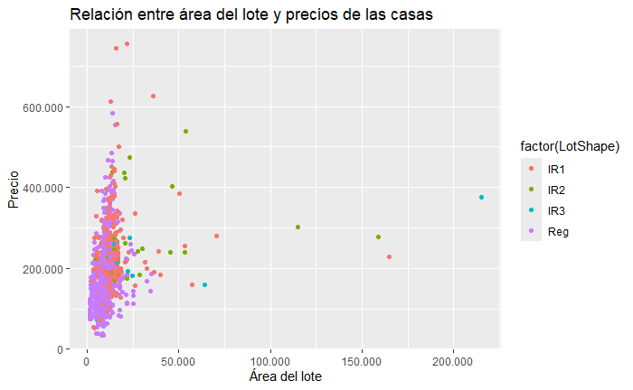

```r
library(scales)
library(dplyr)

df %>%
  ggplot(aes(x = LotArea, y = SalePrice)) +
  geom_point(aes(colour = factor(LotShape))) +
  labs(title = "Relación entre área del lote y precios de las casas",
       x = "Área del lote",
       y = "Precio") +
  scale_y_continuous(labels = label_number(big.mark = ".", decimal.mark = ",")) +  # Formato sin notación científica
  scale_x_continuous(labels = label_number(big.mark = ".", decimal.mark = ","))    # También aplica al eje X si es necesario
```

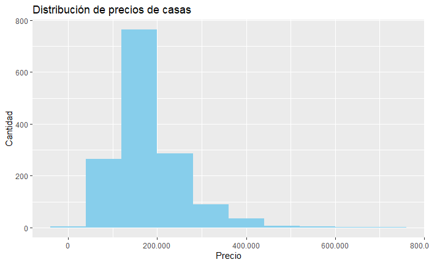

```r
df %>%
  ggplot(aes(x = SalePrice)) +
  geom_histogram(bins = 10, fill = "skyblue") +
  labs(title = "Distribución de precios de casas", x = "Precio", y = "Cantidad") +
  scale_x_continuous(labels = label_number(big.mark = ".", decimal.mark = ","))
```

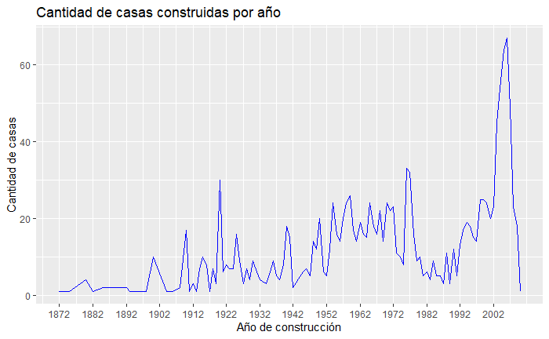

```r
df %>%
  group_by(YearBuilt) %>%
  summarize(CantidadCasas = n()) %>%  # n() cuenta las casas por año
  ggplot(aes(x = YearBuilt, y = CantidadCasas)) +
  geom_line(color = "blue") +  # Dibuja la línea
  labs(title = "Cantidad de casas construidas por año",
       x = "Año de construcción",
       y = "Cantidad de casas") +
  scale_x_continuous(breaks = seq(min(df$YearBuilt), max(df$YearBuilt), by = 10))
```

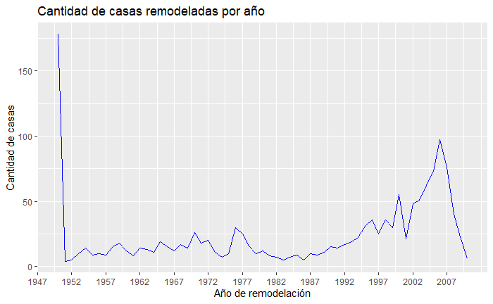

```r
df %>%
  group_by(YearRemodAdd) %>%
  summarize(CantidadCasas = n()) %>%  # n() cuenta las casas por año
  ggplot(aes(x = YearRemodAdd, y = CantidadCasas)) +
  geom_line(color = "blue") +  # Dibuja la línea
  labs(title = "Cantidad de casas remodeladas por año",
       x = "Año de remodelación",
       y = "Cantidad de casas") +
  scale_x_continuous(breaks = seq(min(df$YearBuilt), max(df$YearBuilt), by = 5))
```

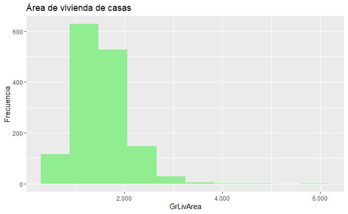

```r
df %>%
  ggplot(aes(x = GrLivArea)) +
  geom_histogram(bins = 10, fill = "lightgreen") +
  labs(title = "Área de vivienda de casas",
       X = "Área", y = "Frecuencia") +
  scale_x_continuous(labels = label_number(big.mark = ".", decimal.mark = ","))
```

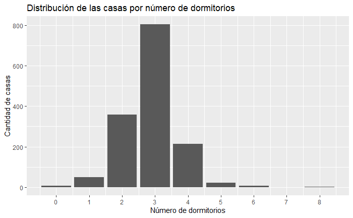

```r
df %>%
  ggplot(aes(x = BedroomAbvGr)) +
  geom_bar() +
  scale_x_continuous(breaks = seq(min(df$BedroomAbvGr), max(df$BedroomAbvGr), by = 1)) +  # Etiquetas de 1 en 1
  labs(title = "Distribución de las casas por número de dormitorios",
       x = "Número de dormitorios",
       y = "Cantidad de casas")
```

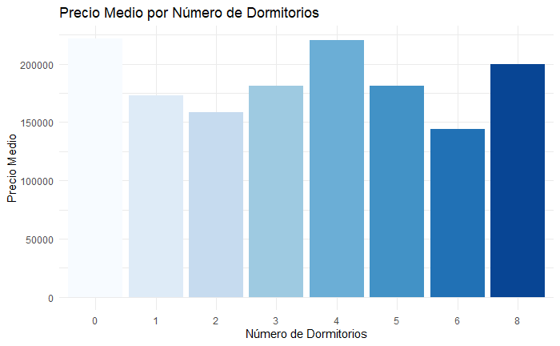

```r
library(ggplot2)
library(dplyr)

df %>%
  group_by(BedroomAbvGr) %>%
  summarize(MeanPrice = mean(SalePrice, na.rm = TRUE)) %>%
  ggplot(aes(x = factor(BedroomAbvGr), y = MeanPrice, fill = factor(BedroomAbvGr))) +
  geom_col(show.legend = FALSE) +  # Gráfico de barras
  scale_fill_brewer(palette = "Blues") +  # Cambia la paleta de colores para valores discretos
  labs(title = "Precio Medio por Número de Dormitorios",
       x = "Número de Dormitorios",
       y = "Precio Medio") +
  theme_minimal()
```

```r
NA
NA
NA
```

Nos damos cuenta que debemos eliminar 6 registros, no tiene sentido que haya una casa sin dormitorios.Y que en promedio, sean las de mayor valor.

```r
df %>%
  filter(BedroomAbvGr < 1) %>%
  select(SalePrice)
```

| SalePrice |
| --- |
| 385000 |
| 286000 |
| 144000 |
| 108959 |
| 145000 |
| 260000 |

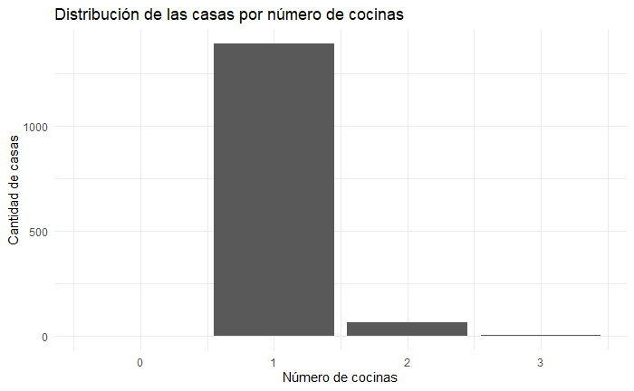

```r
df %>%
  ggplot(aes(x = KitchenAbvGr)) +
  geom_bar() +
  scale_x_continuous(breaks = seq(min(df$KitchenAbvGr), max(df$KitchenAbvGr), by = 1)) +  # Etiquetas de 1 en 1
  labs(title = "Distribución de las casas por número de cocinas",
       x = "Número de cocinas",
       y = "Cantidad de casas") +
  theme_minimal()
```

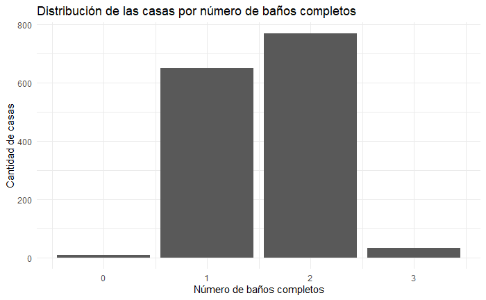

```r
df %>%
  ggplot(aes(x = FullBath)) +
  geom_bar() +
  scale_x_continuous(breaks = seq(min(df$FullBath), max(df$FullBath), by = 1)) +  # Etiquetas de 1 en 1
  labs(title = "Distribución de las casas por número de baños completos",
       x = "Número de baños completos",
       y = "Cantidad de casas") +
  theme_minimal()
```

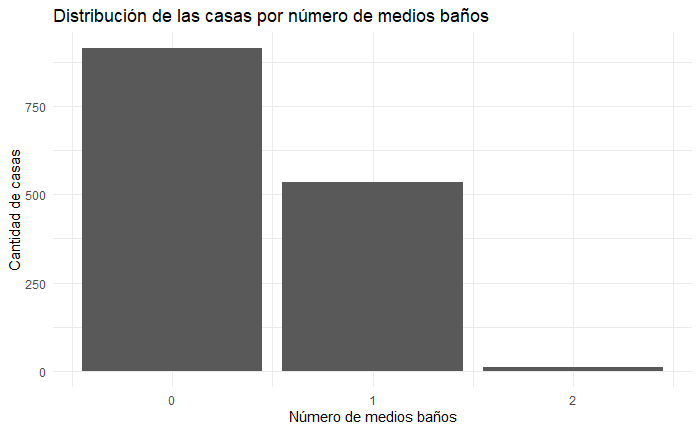

```r
df %>%
  ggplot(aes(x = HalfBath)) +
  geom_bar() +
  scale_x_continuous(breaks = seq(min(df$HalfBath), max(df$HalfBath), by = 1)) +  # Etiquetas de 1 en 1
  labs(title = "Distribución de las casas por número de medios baños",
       x = "Número de medios baños",
       y = "Cantidad de casas") +
  theme_minimal()
```

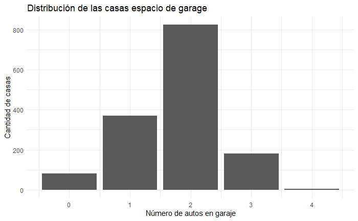

```r
df %>%
  ggplot(aes(x = GarageCars)) +
  geom_bar() +
  scale_x_continuous(breaks = seq(min(df$GarageCars), max(df$GarageCars), by = 1)) +  # Etiquetas de 1 en 1
  labs(title = "Distribución de las casas espacio de garage",
       x = "Número de autos en garaje",
       y = "Cantidad de casas") +
  theme_minimal()
```

## Paso 3: Limpieza de datos

Nos quedamos con las columnas necesarias, antes mencionamos cuales nos quedaríamos

```r
df <- df[, c("LotShape", "HouseStyle", "MSZoning", "OverallQual", "OverallCond",
               "LotArea", "GrLivArea", "BedroomAbvGr", "SalePrice",
               "YrSold", "MoSold", "YearBuilt", "YearRemodAdd")
]
```

Verificamos nuevamente que no hay valores faltantes:

```r
skim(df)
```

```
── Data Summary ────────────────────────
                           Values
Name                       df
Number of rows             1460
Number of columns          13
_______________________
Column type frequency:
  character                3
  numeric                  10
________________________
Group variables            None
```

|  | skim_variable | n_missing | complete_rate | min | max | empty | n_unique | whitespace |
| --- | --- | --- | --- | --- | --- | --- | --- | --- |
| 1 | LotShape | 0 | 1 | 3 | 3 | 0 | 4 | 0 |
| 2 | HouseStyle | 0 | 1 | 4 | 6 | 0 | 8 | 0 |
| 3 | MSZoning | 0 | 1 | 2 | 7 | 0 | 5 | 0 |

|  | skim_variable | n_missing | complete_rate | mean | sd | p0 | p25 | p50 | p75 | p100 | hist |
| --- | --- | --- | --- | --- | --- | --- | --- | --- | --- | --- | --- |
| 1 | OverallQual | 0 | 1 | 6.099315e+00 | 1.382997 | 1 | 5.0 | 6.0 | 7.00 | 10 | ▁▂▇▅▁ |
| 2 | OverallCond | 0 | 1 | 5.575342e+00 | 1.112799 | 1 | 5.0 | 5.0 | 6.00 | 9 | ▁▁▇▅▁ |
| 3 | LotArea | 0 | 1 | 1.051683e+04 | 9981.264932 | 1300 | 7553.5 | 9478.5 | 11601.50 | 215245 | ▇▁▁▁▁ |
| 4 | GrLivArea | 0 | 1 | 1.515464e+03 | 525.480383 | 334 | 1129.5 | 1464.0 | 1776.75 | 5642 | ▇▇▁▁▁ |
| 5 | BedroomAbvGr | 0 | 1 | 2.866438e+00 | 0.815778 | 0 | 2.0 | 3.0 | 3.00 | 8 | ▁▇▂▁▁ |
| 6 | SalePrice | 0 | 1 | 1.809212e+05 | 79442.502883 | 34900 | 129975.0 | 163000.0 | 214000.00 | 755000 | ▇▅▁▁▁ |
| 7 | YrSold | 0 | 1 | 2.007816e+03 | 1.328095 | 2006 | 2007.0 | 2008.0 | 2009.00 | 2010 | ▇▇▇▇▅ |
| 8 | MoSold | 0 | 1 | 6.321918e+00 | 2.703626 | 1 | 5.0 | 6.0 | 8.00 | 12 | ▃▆▇▃▃ |
| 9 | YearBuilt | 0 | 1 | 1.971268e+03 | 30.202904 | 1872 | 1954.0 | 1973.0 | 2000.00 | 2010 | ▁▂▃▆▇ |
| 10 | YearRemodAdd | 0 | 1 | 1.984866e+03 | 20.645407 | 1950 | 1967.0 | 1994.0 | 2004.00 | 2010 | ▅▂▂▃▇ |

No hay valores faltantes, no es necesaria la imputación.Sin embargo, eliminaremos los valores sin sentido encontrados anteriormente.

## Paso 4: Manejo de Outliers

La variable numérica de mayor relevancia es el precio de venta de las casas, de hecho, sería nuestra variable objetivo en un modelo predictivo. Las áreas de lotes y viviendas también se pueden considerar.

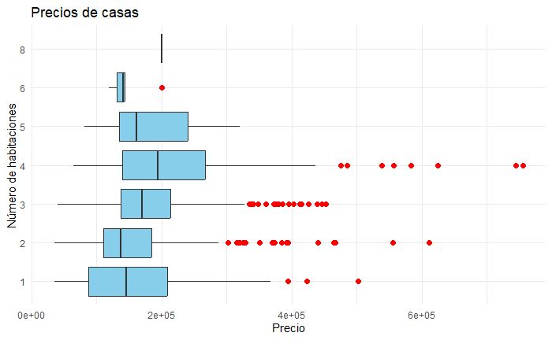

```r
df %>%
  ggplot(aes(y = factor(BedroomAbvGr), x = SalePrice)) +
  geom_boxplot(outlier.colour = "red", outlier.shape = 16, outlier.size = 2, fill = "skyblue") +
  labs(title = "Precios de casas",
       y = "Número de habitaciones",
       x = "Precio") +
  theme_minimal()
```

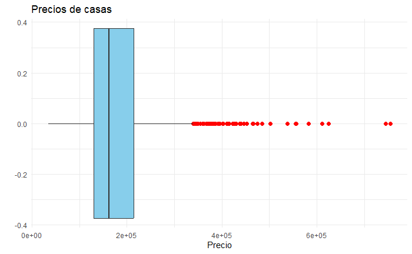

```r
df %>%
  ggplot(aes(x = SalePrice)) +
  geom_boxplot(outlier.colour = "red", outlier.shape = 16, outlier.size = 2, fill = "skyblue") +
  labs(title = "Precios de casas",
       y = "",
       x = "Precio") +
  theme_minimal()
```

```r
df %>%
  filter(BedroomAbvGr == 8)
```

| LotShape | HouseStyle | MSZoning | OverallQual | OverallCond | LotArea | GrLivArea | BedroomAbvGr | SalePrice | YrSold | MoSold | YearBuilt | YearRemodAdd |
| --- | --- | --- | --- | --- | --- | --- | --- | --- | --- | --- | --- | --- |
| Reg | 2.5Fin | RH | 6 | 7 | 10896 | 3395 | 8 | 200000 | 2007 | 3 | 1914 | 1995 |

Uso de IQR para mostrar los outliers

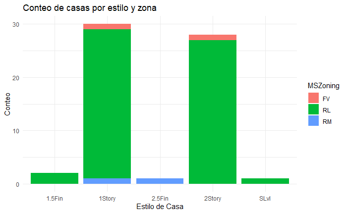

```r
Q1 <- quantile(df$SalePrice, 0.25)
Q3 <- quantile(df$SalePrice, 0.75)
IQR <- Q3 - Q1

l <- Q1 - 1.5 * IQR
u <- Q3 + 1.5 * IQR

df %>%
  filter(SalePrice < l | SalePrice > u) %>%
  ggplot(aes(x = HouseStyle, fill = MSZoning)) +
  geom_bar() +
  labs(title = "Conteo de casas por estilo y zona",
       x = "Estilo de Casa",
       y = "Conteo") +
  theme_minimal()
```

Estos outliers parecen datos con sentido, solamente que las casas que están presentes son bastante más lujosas que las demás. No es conveniente eliminar estos outliers, pero si podríamos querer reducir su impacto al correr algún modelo. Una solución es reemplazar estos valores por valores cercanos a los límites para reducir este impacto.

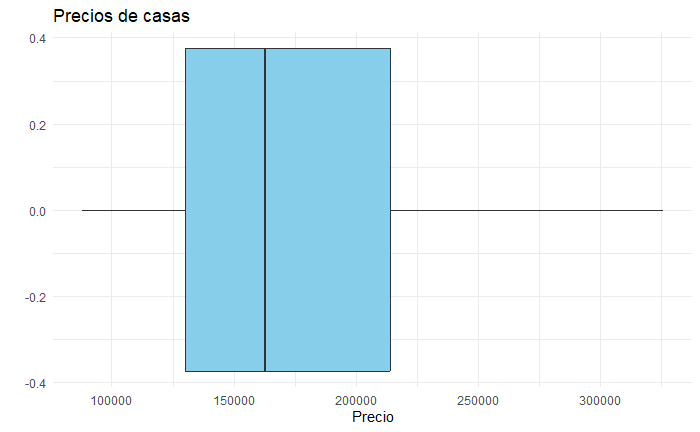

```r
library(DescTools)
?Winsorize

df$SalePrice_win <- Winsorize(df$SalePrice, val = quantile(df$SalePrice, probs = c(0.05, 0.95), na.rm = TRUE))

df %>%
  ggplot(aes(x = SalePrice_win)) +
  geom_boxplot(outlier.colour = "red", outlier.shape = 16, outlier.size = 2, fill = "skyblue") +
  labs(title = "Precios de casas",
       y = "",
       x = "Precio") +
  theme_minimal()
```

Verificamos que no hay outliers en el gráfico de BoxPlot nuevamente.

Paso 5: Transformación de Variables

**Aplicamos min-max scaling**  
Es bueno hacer esto a varibales continuas, no hacerlo con variables numéricas ordinales como podrían ser ratings, cantidad de habitaciones o fechas. Generalmente el min-max scaling se usa cuando queremos que dos o más variables se encuentren en el mismo rango, así ninguna tendrá demasiado peso.

```r
var_scale <- c("LotArea", "GrLivArea", "SalePrice")

df_normalizado <- df %>%
  mutate(across(all_of(var_scale), ~ rescale(.)))

summary(df_normalizado)
```

```
   LotShape          HouseStyle          MSZoning          OverallQual      OverallCond       LotArea          GrLivArea       BedroomAbvGr     SalePrice          YrSold         MoSold
 Length:1454        Length:1454        Length:1454        Min.   : 1.000   Min.   :1.000   Min.   :0.00000   Min.   :0.0000   Min.   :1.000   Min.   :0.0000   Min.   :2006   Min.   : 1.000
 Class :character   Class :character   Class :character   1st Qu.: 5.000   1st Qu.:5.000   1st Qu.:0.02925   1st Qu.:0.1500   1st Qu.:2.000   1st Qu.:0.1320   1st Qu.:2007   1st Qu.: 5.000
 Mode  :character   Mode  :character   Mode  :character   Median : 6.000   Median :5.000   Median :0.03821   Median :0.2129   Median :3.000   Median :0.1779   Median :2008   Median : 6.000
                                                          Mean   : 6.098   Mean   :5.575   Mean   :0.04293   Mean   :0.2227   Mean   :2.878   Mean   :0.2025   Mean   :2008   Mean   : 6.324
                                                          3rd Qu.: 7.000   3rd Qu.:6.000   3rd Qu.:0.04814   3rd Qu.:0.2721   3rd Qu.:3.000   3rd Qu.:0.2485   3rd Qu.:2009   3rd Qu.: 8.000
                                                          Max.   :10.000   Max.   :9.000   Max.   :1.00000   Max.   :1.0000   Max.   :8.000   Max.   :1.0000   Max.   :2010   Max.   :12.000
   YearBuilt     YearRemodAdd  SalePrice_win
 Min.   :1872   Min.   :1950   Min.   : 88000
 1st Qu.:1954   1st Qu.:1966   1st Qu.:129925
 Median :1972   Median :1994   Median :163000
 Mean   :1971   Mean   :1985   Mean   :177206
 3rd Qu.:2000   3rd Qu.:2004   3rd Qu.:213875
 Max.   :2010   Max.   :2010   Max.   :325756
```

**Estandarización** Es más útil cuando tenemos una distribución normal, o usaremos modelos que dependen de que distribución de nuestros datos sea Gaussiana.

```r
df_standardized <- df %>%
  mutate(across(all_of(var_scale), ~ scale(.)))

summary(df_standardized)
```

```
   LotShape          HouseStyle          MSZoning          OverallQual      OverallCond        LotArea.V1         GrLivArea.V1      BedroomAbvGr      SalePrice.V1         YrSold         MoSold
 Length:1454        Length:1454        Length:1454        Min.   : 1.000   Min.   :1.000   Min.   :-0.924109   Min.   :-2.246795   Min.   :1.000   Min.   :-1.838871   Min.   :2006   Min.   : 1.000
 Class :character   Class :character   Class :character   1st Qu.: 5.000   1st Qu.:5.000   1st Qu.:-0.294459   1st Qu.:-0.733320   1st Qu.:2.000   1st Qu.:-0.640831   1st Qu.:2007   1st Qu.: 5.000
 Mode  :character   Mode  :character   Mode  :character   Median : 6.000   Median :5.000   Median :-0.101645   Median :-0.098944   Median :3.000   Median :-0.223833   Median :2008   Median : 6.000
                                                          Mean   : 6.098   Mean   :5.575   Mean   : 0.000000   Mean   : 0.000000   Mean   :2.878   Mean   : 0.000000   Mean   :2008   Mean   : 6.324
                                                          3rd Qu.: 7.000   3rd Qu.:6.000   3rd Qu.: 0.112145   3rd Qu.: 0.498368   3rd Qu.:3.000   3rd Qu.: 0.417580   3rd Qu.:2009   3rd Qu.: 8.000
                                                          Max.   :10.000   Max.   :9.000   Max.   :20.600300   Max.   : 7.842405   Max.   :8.000   Max.   : 7.239888   Max.   :2010   Max.   :12.000
   YearBuilt     YearRemodAdd  SalePrice_win
 Min.   :1872   Min.   :1950   Min.   : 88000
 1st Qu.:1954   1st Qu.:1966   1st Qu.:129925
 Median :1972   Median :1994   Median :163000
 Mean   :1971   Mean   :1985   Mean   :177206
 3rd Qu.:2000   3rd Qu.:2004   3rd Qu.:213875
 Max.   :2010   Max.   :2010   Max.   :325756
```

### **Transformación logarítmica**

La transformación logarítmica es una buena manera de lidiar con outliers, por esta razón. Veamos el gráfico de densidad antes y después de aplicar logaritmos:

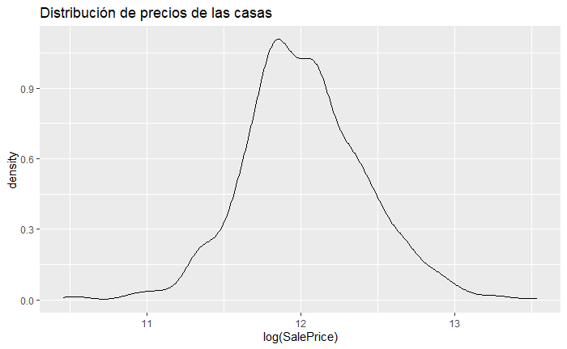

```r
df %>%
  ggplot(aes(log(SalePrice))) +
  geom_density()+
  labs(title = "Distribución de precios de las casas")
```

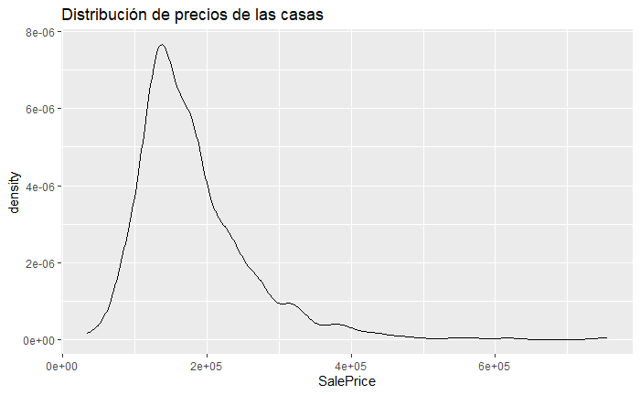

```r
  #aes(colour = factor(YrSold))

df %>%
  ggplot(aes(SalePrice)) +
  geom_density()+
  labs(title = "Distribución de precios de las casas")
```

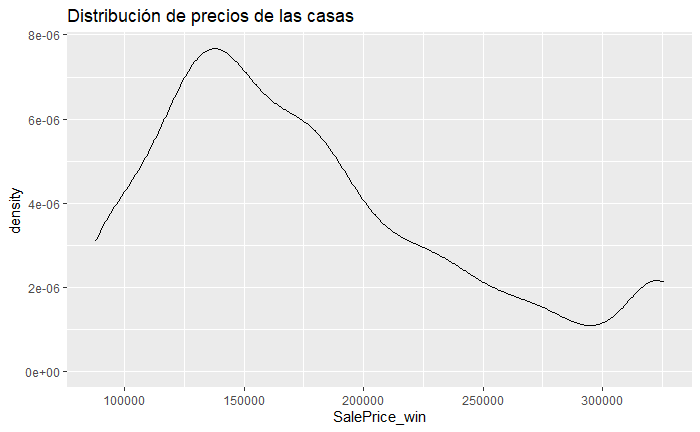

```r
  #aes(colour = factor(YrSold))

df %>%
  ggplot(aes(SalePrice_win)) +
  geom_density()+
  labs(title = "Distribución de precios de las casas")
```

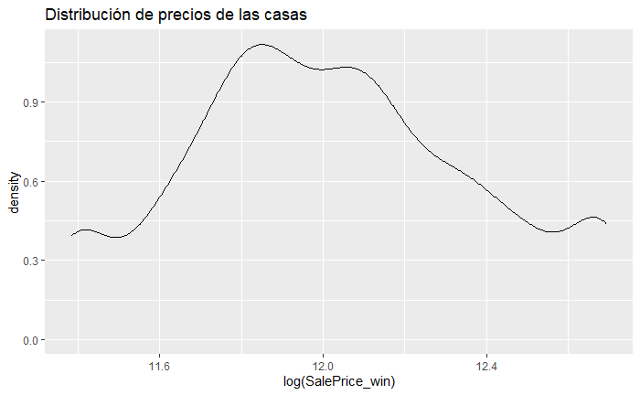

```r
  #aes(colour = factor(YrSold))

df %>%
  ggplot(aes(log(SalePrice_win))) +
  geom_density()+
  labs(title = "Distribución de precios de las casas")
```

```r
  #aes(colour = factor(YrSold))
```

Notemos como la distribución se vuelve más simétrica, aunque quedarían outlier, si aplicamos logaritmos a la variable winsorizada debería acabar el problema.

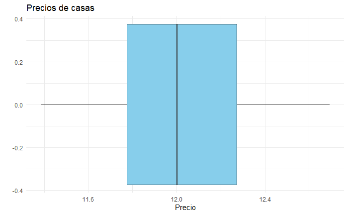

```r
df %>%
  ggplot(aes(x = log(SalePrice_win))) +
  geom_boxplot(outlier.colour = "red", outlier.shape = 16, outlier.size = 2, fill = "skyblue") +
  labs(title = "Precios de casas",
       y = "",
       x = "Precio") +
  theme_minimal()
```

## 6. Ingeniería de características

### Creación de nuevas variables

Saber la “edad” de la casa al momento de su venta, al igual que cuanto tiempo tenía de haber sido remodelada podría ser un factor determinante para el precio, más fácil de trabajar que años.

```r
df$HouseAge = df$YrSold - df$YearBuilt
df$YrAfterRemod = df$YrSold - df$YearRemodAdd

df %>%
  select(c(HouseAge, YrAfterRemod))
```

|  | HouseAge | YrAfterRemod |
| --- | --- | --- |
| 1 | 5 | 5 |
| 2 | 31 | 31 |
| 3 | 7 | 6 |
| 4 | 91 | 36 |
| 5 | 8 | 8 |
| 6 | 16 | 14 |
| 7 | 3 | 2 |
| 8 | 36 | 36 |
| 9 | 77 | 58 |
| 10 | 69 | 58 |

[output cut: 990 more lines]

```r
NA
```

Podemos centrarnos más en factores como lujos, calidad, etc, si dejamos el tamaño de la casa de lado. Podríamos estimar el precio del pie cuadrado en cierta zona, por ejemplo.

```r
df$PriceSqrFt = df$SalePrice / df$LotArea
```

### Codificación de variables categóricas

```r
library(fastDummies)
df <- dummy_cols(df, select_columns = c("LotShape", "HouseStyle"), remove_first_dummy = TRUE)
```

## Paso 7: Análisis Comparativo

```r
skim(df_copy)
```

```
── Data Summary ────────────────────────
                           Values
Name                       df_copy
Number of rows             1460
Number of columns          81
_______________________
Column type frequency:
  character                43
  numeric                  38
________________________
Group variables            None
```

|  | skim_variable | n_missing | complete_rate | min | max | empty | n_unique | whitespace |
| --- | --- | --- | --- | --- | --- | --- | --- | --- |
| 1 | MSZoning | 0 | 1.000000000 | 2 | 7 | 0 | 5 | 0 |
| 2 | Street | 0 | 1.000000000 | 4 | 4 | 0 | 2 | 0 |
| 3 | Alley | 1369 | 0.062328767 | 4 | 4 | 0 | 2 | 0 |
| 4 | LotShape | 0 | 1.000000000 | 3 | 3 | 0 | 4 | 0 |
| 5 | LandContour | 0 | 1.000000000 | 3 | 3 | 0 | 4 | 0 |
| 6 | Utilities | 0 | 1.000000000 | 6 | 6 | 0 | 2 | 0 |
| 7 | LotConfig | 0 | 1.000000000 | 3 | 7 | 0 | 5 | 0 |
| 8 | LandSlope | 0 | 1.000000000 | 3 | 3 | 0 | 3 | 0 |
| 9 | Neighborhood | 0 | 1.000000000 | 5 | 7 | 0 | 25 | 0 |
| 10 | Condition1 | 0 | 1.000000000 | 4 | 6 | 0 | 9 | 0 |

[output cut: 33 more lines]

|  | skim_variable | n_missing | complete_rate | mean | sd | p0 | p25 | p50 | p75 | p100 | hist |
| --- | --- | --- | --- | --- | --- | --- | --- | --- | --- | --- | --- |
| 1 | Id | 0 | 1.0000000 | 7.305000e+02 | 4.216100e+02 | 1 | 365.75 | 730.5 | 1095.25 | 1460 | ▇▇▇▇▇ |
| 2 | MSSubClass | 0 | 1.0000000 | 5.689726e+01 | 4.230057e+01 | 20 | 20.00 | 50.0 | 70.00 | 190 | ▇▅▂▁▁ |
| 3 | LotFrontage | 259 | 0.8226027 | 7.004996e+01 | 2.428475e+01 | 21 | 59.00 | 69.0 | 80.00 | 313 | ▇▃▁▁▁ |
| 4 | LotArea | 0 | 1.0000000 | 1.051683e+04 | 9.981265e+03 | 1300 | 7553.50 | 9478.5 | 11601.50 | 215245 | ▇▁▁▁▁ |
| 5 | OverallQual | 0 | 1.0000000 | 6.099315e+00 | 1.382997e+00 | 1 | 5.00 | 6.0 | 7.00 | 10 | ▁▂▇▅▁ |
| 6 | OverallCond | 0 | 1.0000000 | 5.575342e+00 | 1.112799e+00 | 1 | 5.00 | 5.0 | 6.00 | 9 | ▁▁▇▅▁ |
| 7 | YearBuilt | 0 | 1.0000000 | 1.971268e+03 | 3.020290e+01 | 1872 | 1954.00 | 1973.0 | 2000.00 | 2010 | ▁▂▃▆▇ |
| 8 | YearRemodAdd | 0 | 1.0000000 | 1.984866e+03 | 2.064541e+01 | 1950 | 1967.00 | 1994.0 | 2004.00 | 2010 | ▅▂▂▃▇ |
| 9 | MasVnrArea | 8 | 0.9945205 | 1.036853e+02 | 1.810662e+02 | 0 | 0.00 | 0.0 | 166.00 | 1600 | ▇▁▁▁▁ |
| 10 | BsmtFinSF1 | 0 | 1.0000000 | 4.436397e+02 | 4.560981e+02 | 0 | 0.00 | 383.5 | 712.25 | 5644 | ▇▁▁▁▁ |

[output cut: 28 more lines]

```r
skim(df_normalizado)
```

```
── Data Summary ────────────────────────
                           Values
Name                       df_normalizado
Number of rows             1454
Number of columns          14
_______________________
Column type frequency:
  character                3
  numeric                  11
________________________
Group variables            None
```

|  | skim_variable | n_missing | complete_rate | min | max | empty | n_unique | whitespace |
| --- | --- | --- | --- | --- | --- | --- | --- | --- |
| 1 | LotShape | 0 | 1 | 3 | 3 | 0 | 4 | 0 |
| 2 | HouseStyle | 0 | 1 | 4 | 6 | 0 | 8 | 0 |
| 3 | MSZoning | 0 | 1 | 2 | 7 | 0 | 5 | 0 |

|  | skim_variable | n_missing | complete_rate | mean | sd | p0 | p25 | p50 | p75 | p100 | hist |
| --- | --- | --- | --- | --- | --- | --- | --- | --- | --- | --- | --- |
| 1 | OverallQual | 0 | 1 | 6.098349e+00 | 1.380459e+00 | 1 | 5.000000e+00 | 6.000000e+00 | 7.000000e+00 | 10.0 | ▁▂▇▅▁ |
| 2 | OverallCond | 0 | 1 | 5.574966e+00 | 1.110337e+00 | 1 | 5.000000e+00 | 5.000000e+00 | 6.000000e+00 | 9.0 | ▁▁▇▅▁ |
| 3 | LotArea | 0 | 1 | 4.293309e-02 | 4.645888e-02 | 0 | 2.925285e-02 | 3.821076e-02 | 4.814321e-02 | 1.0 | ▇▁▁▁▁ |
| 4 | GrLivArea | 0 | 1 | 2.226931e-01 | 9.911589e-02 | 0 | 1.500094e-01 | 2.128862e-01 | 2.720893e-01 | 1.0 | ▇▇▁▁▁ |
| 5 | BedroomAbvGr | 0 | 1 | 2.878267e+00 | 7.963497e-01 | 1 | 2.000000e+00 | 3.000000e+00 | 3.000000e+00 | 8.0 | ▅▇▂▁▁ |
| 6 | SalePrice | 0 | 1 | 2.025466e-01 | 1.101472e-01 | 0 | 1.319608e-01 | 1.778920e-01 | 2.485419e-01 | 1.0 | ▇▅▁▁▁ |
| 7 | YrSold | 0 | 1 | 2.007815e+03 | 1.326638e+00 | 2006 | 2.007000e+03 | 2.008000e+03 | 2.009000e+03 | 2010.0 | ▇▇▇▇▅ |
| 8 | MoSold | 0 | 1 | 6.323934e+00 | 2.701536e+00 | 1 | 5.000000e+00 | 6.000000e+00 | 8.000000e+00 | 12.0 | ▃▆▇▃▃ |
| 9 | YearBuilt | 0 | 1 | 1.971235e+03 | 3.025200e+01 | 1872 | 1.954000e+03 | 1.972500e+03 | 2.000000e+03 | 2010.0 | ▁▂▃▆▇ |
| 10 | YearRemodAdd | 0 | 1 | 1.984860e+03 | 2.067354e+01 | 1950 | 1.966250e+03 | 1.994000e+03 | 2.004000e+03 | 2010.0 | ▅▂▂▃▇ |

[output cut: 1 more lines]

```r
skim(df_standardized)
```

```
── Data Summary ────────────────────────
                           Values
Name                       df_standardized
Number of rows             1454
Number of columns          14
_______________________
Column type frequency:
  character                3
  numeric                  11
________________________
Group variables            None
```

|  | skim_variable | n_missing | complete_rate | min | max | empty | n_unique | whitespace |
| --- | --- | --- | --- | --- | --- | --- | --- | --- |
| 1 | LotShape | 0 | 1 | 3 | 3 | 0 | 4 | 0 |
| 2 | HouseStyle | 0 | 1 | 4 | 6 | 0 | 8 | 0 |
| 3 | MSZoning | 0 | 1 | 2 | 7 | 0 | 5 | 0 |

|  | skim_variable | n_missing | complete_rate | mean | sd | p0 | p25 | p50 | p75 | p100 | hist |
| --- | --- | --- | --- | --- | --- | --- | --- | --- | --- | --- | --- |
| 1 | OverallQual | 0 | 1 | 6.098349e+00 | 1.380459e+00 | 1.0000000 | 5.000000e+00 | 6.000000e+00 | 7.000000e+00 | 1.000000e+01 | ▁▂▇▅▁ |
| 2 | OverallCond | 0 | 1 | 5.574966e+00 | 1.110337e+00 | 1.0000000 | 5.000000e+00 | 5.000000e+00 | 6.000000e+00 | 9.000000e+00 | ▁▁▇▅▁ |
| 3 | LotArea | 0 | 1 | -7.589814e-17 | 1.000000e+00 | -0.9241094 | -2.944592e-01 | -1.016455e-01 | 1.121449e-01 | 2.060030e+01 | ▇▁▁▁▁ |
| 4 | GrLivArea | 0 | 1 | -3.381510e-17 | 1.000000e+00 | -2.2467953 | -7.333203e-01 | -9.894377e-02 | 4.983681e-01 | 7.842405e+00 | ▇▇▁▁▁ |
| 5 | BedroomAbvGr | 0 | 1 | 2.878267e+00 | 7.963497e-01 | 1.0000000 | 2.000000e+00 | 3.000000e+00 | 3.000000e+00 | 8.000000e+00 | ▅▇▂▁▁ |
| 6 | SalePrice | 0 | 1 | -5.986992e-17 | 1.000000e+00 | -1.8388714 | -6.408307e-01 | -2.238331e-01 | 4.175804e-01 | 7.239888e+00 | ▇▅▁▁▁ |
| 7 | YrSold | 0 | 1 | 2.007815e+03 | 1.326638e+00 | 2006.0000000 | 2.007000e+03 | 2.008000e+03 | 2.009000e+03 | 2.010000e+03 | ▇▇▇▇▅ |
| 8 | MoSold | 0 | 1 | 6.323934e+00 | 2.701536e+00 | 1.0000000 | 5.000000e+00 | 6.000000e+00 | 8.000000e+00 | 1.200000e+01 | ▃▆▇▃▃ |
| 9 | YearBuilt | 0 | 1 | 1.971235e+03 | 3.025200e+01 | 1872.0000000 | 1.954000e+03 | 1.972500e+03 | 2.000000e+03 | 2.010000e+03 | ▁▂▃▆▇ |
| 10 | YearRemodAdd | 0 | 1 | 1.984860e+03 | 2.067354e+01 | 1950.0000000 | 1.966250e+03 | 1.994000e+03 | 2.004000e+03 | 2.010000e+03 | ▅▂▂▃▇ |

[output cut: 1 more lines]

```r
skim(df)
```

```
── Data Summary ────────────────────────
                           Values
Name                       df
Number of rows             1454
Number of columns          27
_______________________
Column type frequency:
  character                3
  numeric                  24
________________________
Group variables            None
```

|  | skim_variable | n_missing | complete_rate | min | max | empty | n_unique | whitespace |
| --- | --- | --- | --- | --- | --- | --- | --- | --- |
| 1 | LotShape | 0 | 1 | 3 | 3 | 0 | 4 | 0 |
| 2 | HouseStyle | 0 | 1 | 4 | 6 | 0 | 8 | 0 |
| 3 | MSZoning | 0 | 1 | 2 | 7 | 0 | 5 | 0 |

|  | skim_variable | n_missing | complete_rate | mean | sd | p0 | p25 | p50 | p75 | p100 | hist |
| --- | --- | --- | --- | --- | --- | --- | --- | --- | --- | --- | --- |
| 1 | OverallQual | 0 | 1 | 6.098349e+00 | 1.380459e+00 | 1.000000 | 5.00000 | 6.00000 | 7.00000 | 10.00000 | ▁▂▇▅▁ |
| 2 | OverallCond | 0 | 1 | 5.574966e+00 | 1.110337e+00 | 1.000000 | 5.00000 | 5.00000 | 6.00000 | 9.00000 | ▁▁▇▅▁ |
| 3 | LotArea | 0 | 1 | 1.048532e+04 | 9.939645e+03 | 1300.000000 | 7558.50000 | 9475.00000 | 11600.00000 | 215245.00000 | ▇▁▁▁▁ |
| 4 | GrLivArea | 0 | 1 | 1.516055e+03 | 5.261071e+02 | 334.000000 | 1130.25000 | 1464.00000 | 1778.25000 | 5642.00000 | ▇▇▁▁▁ |
| 5 | BedroomAbvGr | 0 | 1 | 2.878267e+00 | 7.963497e-01 | 1.000000 | 2.00000 | 3.00000 | 3.00000 | 8.00000 | ▅▇▂▁▁ |
| 6 | SalePrice | 0 | 1 | 1.807538e+05 | 7.931701e+04 | 34900.000000 | 129925.00000 | 163000.00000 | 213875.00000 | 755000.00000 | ▇▅▁▁▁ |
| 7 | YrSold | 0 | 1 | 2.007815e+03 | 1.326638e+00 | 2006.000000 | 2007.00000 | 2008.00000 | 2009.00000 | 2010.00000 | ▇▇▇▇▅ |
| 8 | MoSold | 0 | 1 | 6.323934e+00 | 2.701536e+00 | 1.000000 | 5.00000 | 6.00000 | 8.00000 | 12.00000 | ▃▆▇▃▃ |
| 9 | YearBuilt | 0 | 1 | 1.971235e+03 | 3.025200e+01 | 1872.000000 | 1954.00000 | 1972.50000 | 2000.00000 | 2010.00000 | ▁▂▃▆▇ |
| 10 | YearRemodAdd | 0 | 1 | 1.984860e+03 | 2.067354e+01 | 1950.000000 | 1966.25000 | 1994.00000 | 2004.00000 | 2010.00000 | ▅▂▂▃▇ |

[output cut: 14 more lines]

A medida que hemos transformado el dataset hemos hecho una comparativa con el sobre los datos iniciales. Algunos aspectos que han cambiado: